# Содержание

```python
import pandas as pd
import matplotlib.pyplot as plt
import seaborn as sns
import numpy as np
from sklearn.model_selection import train_test_split
from sklearn.preprocessing import StandardScaler
from sklearn.linear_model import LogisticRegression
from sklearn.ensemble import RandomForestClassifier
from sklearn.metrics import accuracy_score, precision_score, recall_score
from scipy.cluster.hierarchy import dendrogram, linkage
from sklearn.cluster import KMeans
```

## Описание проекта

Сеть фитнес-центров «Культурист-датасаентист» разрабатывает стратегию взаимодействия с клиентами на основе аналитических данных. Необходимо провести анализ и подготовить план действий по удержанию клиентов. А именно:

- научиться прогнозировать вероятность оттока (на уровне следующего месяца) для каждого клиента;
- сформировать типичные портреты клиентов: выделить несколько наиболее ярких групп и охарактеризовать их основные свойства;
- проанализировать основные признаки, наиболее сильно влияющие на отток;
- сформулировать основные выводы и разработать рекомендации по повышению качества работы с клиентами:

  ```
    1) выделить целевые группы клиентов;
    2) предложить меры по снижению оттока;
    3) определить другие особенности взаимодействия с клиентами.
  ```

Заказчик подготовил данные, которые содержат данные на месяц до оттока и факт оттока на определённый месяц. Набор данных включает следующие поля:

Данные клиента за предыдущий до проверки факта оттока месяц:

- 'gender' — пол;
- 'Near_Location' — проживание или работа в районе, где находится фитнес-центр;
- 'Partner' — сотрудник компании-партнёра клуба (сотрудничество с компаниями, чьи сотрудники могут получать скидки на абонемент — в таком случае фитнес-центр хранит информацию о работодателе клиента);
- 'Promo_friends' — факт первоначальной записи в рамках акции «приведи друга» (использовал промо-код от знакомого при оплате первого абонемента);
- 'Phone' — наличие контактного телефона;
- 'Age' — возраст;
- 'Lifetime' — время с момента первого обращения в фитнес-центр (в месяцах).

Информация на основе журнала посещений, покупок и информация о текущем статусе абонемента клиента:

- 'Contract_period' — длительность текущего действующего абонемента (месяц, 6 месяцев, год);
- 'Month_to_end_contract' — срок до окончания текущего действующего абонемента (в месяцах);
- 'Group_visits' — факт посещения групповых занятий;
- 'Avg_class_frequency_total' — средняя частота посещений в неделю за все время с начала действия абонемента;
- 'Avg_class_frequency_current_month' — средняя частота посещений в неделю за предыдущий месяц;
- 'Avg_additional_charges_total' — суммарная выручка от других услуг фитнес-центра: кафе, спорттовары, косметический и массажный салон.

'Churn' — факт оттока в текущем месяце.

## Обзор данных

```python
gym_data = pd.read_csv('gym_churn.csv')
```

**Функция для обзора датафрейма**

```python
def df_overview(df):
    print('\nИнформация о таблице\n')
    df.info()
    print('\nПервые строки таблицы')
    display(df.head())
    if df.duplicated().sum()== 0:
        print('\nПолных дубликатов строк в таблице нет')
    else:
        print('\nКоличество полных дубликатов строк в таблице{}\n'.format(df.duplicated().sum()))
    n = 0
    for i in df.columns:
        if df[i].isna().sum() != 0:
            print('\nКоличество пропусков в столбце {} - {}'.format(i, df[i].isna().sum()))
            n += 1
    if n != 0:
        print('Всего пропущенные значения есть в {} столбцах'.format(n))
    else:
        print('В столбцах таблицы нет пропущенных значений')

    print('\nПервичная статистика по таблице')
    display(df.describe().T)
```

```python
df_overview(gym_data)
```

```
Информация о таблице

<class 'pandas.core.frame.DataFrame'>
RangeIndex: 4000 entries, 0 to 3999
Data columns (total 14 columns):
 #   Column                             Non-Null Count  Dtype
---  ------                             --------------  -----
 0   gender                             4000 non-null   int64
 1   Near_Location                      4000 non-null   int64
 2   Partner                            4000 non-null   int64
 3   Promo_friends                      4000 non-null   int64
 4   Phone                              4000 non-null   int64
 5   Contract_period                    4000 non-null   int64
 6   Group_visits                       4000 non-null   int64
 7   Age                                4000 non-null   int64
 8   Avg_additional_charges_total       4000 non-null   float64
 9   Month_to_end_contract              4000 non-null   float64
 10  Lifetime                           4000 non-null   int64
 11  Avg_class_frequency_total          4000 non-null   float64
 12  Avg_class_frequency_current_month  4000 non-null   float64
 13  Churn                              4000 non-null   int64
dtypes: float64(4), int64(10)
memory usage: 437.6 KB

Первые строки таблицы
```

|  | gender | Near_Location | Partner | Promo_friends | Phone | Contract_period | Group_visits | Age | Avg_additional_charges_total | Month_to_end_contract | Lifetime | Avg_class_frequency_total | Avg_class_frequency_current_month | Churn |
| --- | --- | --- | --- | --- | --- | --- | --- | --- | --- | --- | --- | --- | --- | --- |
| 0 | 1 | 1 | 1 | 1 | 0 | 6 | 1 | 29 | 14.227470 | 5.0 | 3 | 0.020398 | 0.000000 | 0 |
| 1 | 0 | 1 | 0 | 0 | 1 | 12 | 1 | 31 | 113.202938 | 12.0 | 7 | 1.922936 | 1.910244 | 0 |
| 2 | 0 | 1 | 1 | 0 | 1 | 1 | 0 | 28 | 129.448479 | 1.0 | 2 | 1.859098 | 1.736502 | 0 |
| 3 | 0 | 1 | 1 | 1 | 1 | 12 | 1 | 33 | 62.669863 | 12.0 | 2 | 3.205633 | 3.357215 | 0 |
| 4 | 1 | 1 | 1 | 1 | 1 | 1 | 0 | 26 | 198.362265 | 1.0 | 3 | 1.113884 | 1.120078 | 0 |

```
Полных дубликатов строк в таблице нет
В столбцах таблицы нет пропущенных значений

Первичная статистика по таблице
```

|  | count | mean | std | min | 25% | 50% | 75% | max |
| --- | --- | --- | --- | --- | --- | --- | --- | --- |
| gender | 4000.0 | 0.510250 | 0.499957 | 0.000000 | 0.000000 | 1.000000 | 1.000000 | 1.000000 |
| Near_Location | 4000.0 | 0.845250 | 0.361711 | 0.000000 | 1.000000 | 1.000000 | 1.000000 | 1.000000 |
| Partner | 4000.0 | 0.486750 | 0.499887 | 0.000000 | 0.000000 | 0.000000 | 1.000000 | 1.000000 |
| Promo_friends | 4000.0 | 0.308500 | 0.461932 | 0.000000 | 0.000000 | 0.000000 | 1.000000 | 1.000000 |
| Phone | 4000.0 | 0.903500 | 0.295313 | 0.000000 | 1.000000 | 1.000000 | 1.000000 | 1.000000 |
| Contract_period | 4000.0 | 4.681250 | 4.549706 | 1.000000 | 1.000000 | 1.000000 | 6.000000 | 12.000000 |
| Group_visits | 4000.0 | 0.412250 | 0.492301 | 0.000000 | 0.000000 | 0.000000 | 1.000000 | 1.000000 |
| Age | 4000.0 | 29.184250 | 3.258367 | 18.000000 | 27.000000 | 29.000000 | 31.000000 | 41.000000 |
| Avg_additional_charges_total | 4000.0 | 146.943728 | 96.355602 | 0.148205 | 68.868830 | 136.220159 | 210.949625 | 552.590740 |
| Month_to_end_contract | 4000.0 | 4.322750 | 4.191297 | 1.000000 | 1.000000 | 1.000000 | 6.000000 | 12.000000 |
| Lifetime | 4000.0 | 3.724750 | 3.749267 | 0.000000 | 1.000000 | 3.000000 | 5.000000 | 31.000000 |
| Avg_class_frequency_total | 4000.0 | 1.879020 | 0.972245 | 0.000000 | 1.180875 | 1.832768 | 2.536078 | 6.023668 |
| Avg_class_frequency_current_month | 4000.0 | 1.767052 | 1.052906 | 0.000000 | 0.963003 | 1.719574 | 2.510336 | 6.146783 |
| Churn | 4000.0 | 0.265250 | 0.441521 | 0.000000 | 0.000000 | 0.000000 | 1.000000 | 1.000000 |

**Что можно исправить:**

- названия столбцов привести к одномо регистру, без использования заглавных букв,
- столбец `Month_to_end_contract` привести к формату `int` , т.к. он содержит целочисленные значения (количество месяцев).

```python
gym_data.columns = gym_data.columns.str.lower()
gym_data.columns
```

```
Index(['gender', 'near_location', 'partner', 'promo_friends', 'phone',
       'contract_period', 'group_visits', 'age',
       'avg_additional_charges_total', 'month_to_end_contract', 'lifetime',
       'avg_class_frequency_total', 'avg_class_frequency_current_month',
       'churn'],
      dtype='object')
```

```python
gym_data['month_to_end_contract'] = gym_data['month_to_end_contract'].astype('int')
gym_data['month_to_end_contract'].dtypes
```

```
dtype('int32')
```

**Основываясь на первичной статистике таблицы можно сделать следующие выводы о клиентах клуба, предствленных в выборке:**

- 51% из них женщины;
- 85% клиентов проживают или работают в районе нахождения фитнес-центра,
- 31% записались в клуб в рамках акции "приведи друга"
- 49% сотрудники компаний-партнеров, получающие скидки на абонемент,
- у сотрудников клуба имеются номера телефонов 90% клиентов, представленных в выборке,
- у как минимум 50% клиентов действующий абонемент только на 1 месяц
- групповые занятия посещают 41% клиентов,
- клуб посещают люди в возрасте от 18 до 41 года, средний возраст клиентов 29 лет,
- средняя суммарная выручка одного клиента от других услуг фитнес-центра 147 единиц,
- можно сказать, что не менее 50% клиентов являются клиентами клуба не больше 3-х месяцев,
- в среднем один клиент посещает клуб около 2-х раз в неделю,
- в текущем месяце перестали посещать клуб 26,5% клиентов из выборки.

## Исследовательский анализ данных

Посмотрим на средние значения по клиентам, которые ушли и тем, которые остались.

```python
gym_data.groupby('churn').mean().T
```

| churn | 0 | 1 |
| --- | --- | --- |
| gender | 0.510037 | 0.510839 |
| near_location | 0.873086 | 0.768143 |
| partner | 0.534195 | 0.355325 |
| promo_friends | 0.353522 | 0.183789 |
| phone | 0.903709 | 0.902922 |
| contract_period | 5.747193 | 1.728558 |
| group_visits | 0.464103 | 0.268615 |
| age | 29.976523 | 26.989632 |
| avg_additional_charges_total | 158.445715 | 115.082899 |
| month_to_end_contract | 5.283089 | 1.662582 |
| lifetime | 4.711807 | 0.990575 |
| avg_class_frequency_total | 2.024876 | 1.474995 |
| avg_class_frequency_current_month | 2.027882 | 1.044546 |

Между оставшимися и ушедшими клиентами есть различия практически по всем средним показателям выборки.

В обеих группах почти одинаковое соотношение мужчин и женщин.

Средний возраст ушедших клиентов 27 лет, оставшихся 30 лет.

Среди клиентов которые ушли, доля живущих или работающих в районе фитнес-центра меньше.

Также среди них меньше клиентов получающих скидки по партнерской программе, пришедших по акции "приведи друга".

Средняя продолжительность абонементов у клиентов, которые остались 6 месяцев, у клиентов которые ушли менее 2-х месяцев, значит подавляющее большинство из них приобрело абонемент на 1 месяц, это подтверждает и показатель среднего времени с момента первого обращения клиента в фитнес клуб: у ушедших он менее 1 месяца, а у оставшихстя чуть меньше 5 месяцев.

Среди ушедших доля посещающих групповые занятия ниже, чем у оставшихся. Также у ушедших клиентов частота посещения фитнес клуба 1,4 раза в неделю, тогда как у оставшихся 2. В целом средняя частота посещений в неделю у ушедших клиентов в последний месяц ниже общей на 29%, у оставшихся же этот показатель остался на уровне общего.

Также ушедшие клиенты приносили меньшую выручку от дополнительных услуг, чем оставшиеся.

**Распределение клиентов на оставшихся и ушедших в зависимости от признаков**

Построим на соотношение оставшихся и ушедших клиентов в зависимости от признаков, имеющих 2 значения (да или нет, мужчина или женщина). У нас в таблице представлено 6 таких признаков построим для них графики.

```
Графики соотношения оставшихся и ушедших клиентов по признакм, имеющим два значения.
```

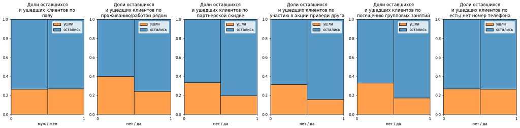

```python
plt.subplots(figsize=(20,5))
selected_columns = [
    'gender',
    'near_location',
    'partner',
    'promo_friends',
    'group_visits',
    'phone'
]
plot_names = [
    'полу',
    'проживанию/работой рядом',
    'партнерской скидке',
    'участию в акции приведи друга',
    'посещению групповых занятий',
    'есть/ нет номер телефона'
]
x_names = [
    'муж / жен',
    'нет / да',
    'нет / да',
    'нет / да',
    'нет / да',
    'нет / да'
]
print('Графики соотношения оставшихся и ушедших клиентов по признакм, имеющим два значения.')
for plot_num, column in enumerate(selected_columns):
    sns.histplot(
        ax=plt.subplot(1, len(selected_columns),plot_num+1),
        data=gym_data,
        x=column,
        hue='churn',
        multiple= 'fill',
        bins = 2
        )
    plt.title(f'Доли оставшихся\nи ушедщих клиентов по \n{plot_names[plot_num]}')
    plt.ylabel('')
    plt.xlabel(x_names[plot_num])
    plt.legend(['ушли', 'остались'])
    plt.xticks([0, 1])
    plt.tight_layout()
```

Как видно доля ушедших клиентов выше в группах:

- не проживает или не работает рядом с фитнес-центром,
- не получает скидку по партнерской программе,
- не пришел по акции "приведи друга"
- не посещает групповые занятия.

Посмотроим на доли оставшихся и ушедших клиентов по признакам, имеющим множество значений. Таких признаков у нас 7.

```
Графики соотношения оставшихся и ушедших клиентов, по признакам, имеющим множественные значения
```

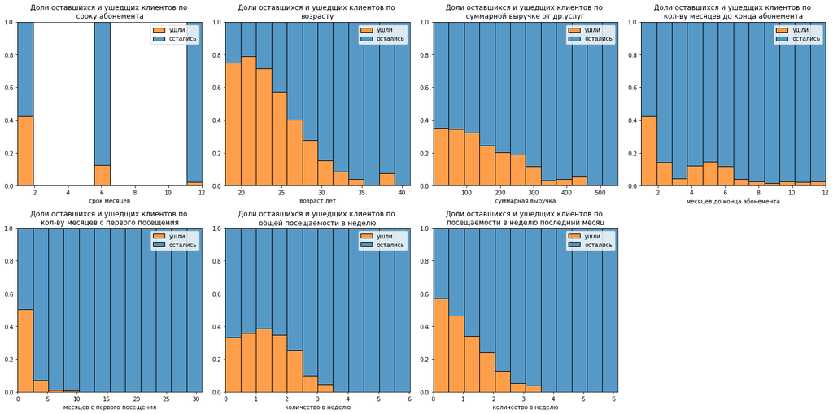

```python
plt.subplots(figsize=(20,10))
selected_columns = [
    'contract_period',
    'age',
    'avg_additional_charges_total',
    'month_to_end_contract',
    'lifetime',
    'avg_class_frequency_total',
    'avg_class_frequency_current_month'
]
plot_names = [
    'сроку абонемента',
    'возрасту',
    'суммарной выручке от др.услуг',
    'кол-ву месяцев до конца абонемента',
    'кол-ву месяцев с первого посещения',
    'общей посещаемости в неделю',
    'посещаемости в неделю последний месяц'
]

x_names = [
    'срок месяцев',
    'возраст лет',
    'суммарная выручка',
    'месяцев до конца абонемента',
    'месяцев с первого посещения',
    'количество в неделю',
    'количество в неделю'
]
print('Графики соотношения оставшихся и ушедших клиентов, по признакам, имеющим множественные значения')
for plot_num, column in enumerate(selected_columns):
    ax = plt.subplot(2, (len(selected_columns)-3),plot_num+1)
    sns.histplot(
        ax=ax,
        data=gym_data,
        x=column,
        hue='churn',
        multiple= 'fill',
        #multiple= 'stack',
        bins = 12
        #palette =['blue', 'red'],
        #alpha = 0.5
        )
    plt.title(f'Доли оставшихся и ушедщих клиентов по \n{plot_names[plot_num]}')
    plt.ylabel('')
    plt.xlabel(x_names[plot_num])
    plt.legend(['ушли', 'остались'])
    plt.tight_layout()
    #plt.xticks([0, 1])
```

Наиболее высокий процент оттока наблюдается:

- среди клиентов с месячным абонементом,
- у клиентов в возрасте до 25,
- у клиентов, чья выручка от других услуг меньше 150 единиц,
- среди клиентов со сроком до конца абонемента 1 месяц,
- в первый месяц посещения фитнес-клуба,
- у клиентов посещающих 1-2 занятия в неделю в среднем,
- у клиентов посещающих 1 занятие и меньше в неделю в среднем в последний месяц.

**Посмотрим на распределение признаков со множеством значений в зависимости от факта оттока.**

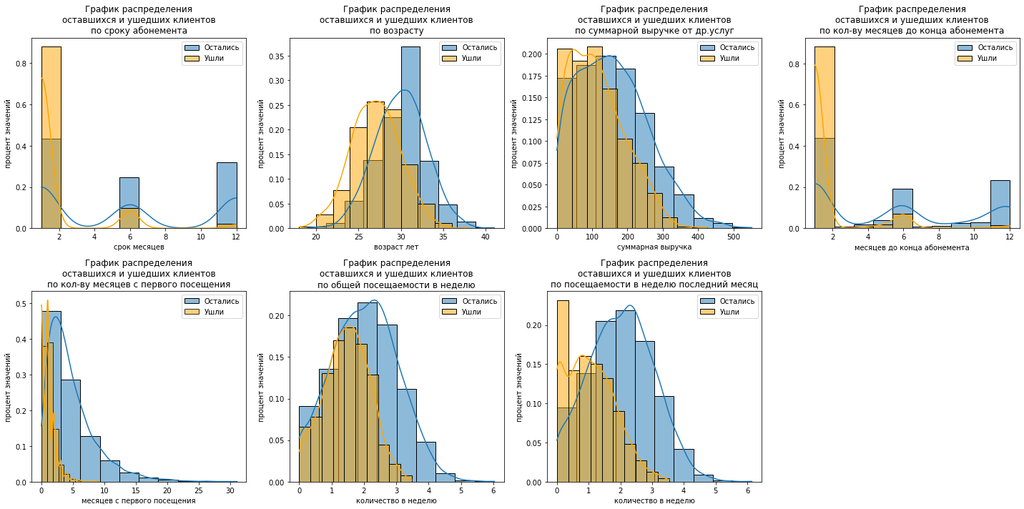

```python
plt.subplots(figsize=(20,10))
for plot_num, column in enumerate(selected_columns):
    ax = plt.subplot(2, (len(selected_columns)-3),plot_num+1)
    sns.histplot(
        gym_data[gym_data['churn']== 0],
        x = column,
        ax=ax,
        bins=10,
        label='Остались',
        #alpha=0.7,
        #stat='density',
        stat='probability',
        common_norm=False,
        kde = True
    )
    sns.histplot(
        gym_data[gym_data['churn']== 1],
        x = column,
        ax=ax,
        bins=10,
        label='Ушли',
        #alpha=0.5,
        color = 'orange',
        #stat='density',
        stat='probability',
        common_norm=False,
        kde = True
        )
    plt.title(f'График распределения\nоставшихся и ушедших клиентов\nпо {plot_names[plot_num]}')
    plt.legend()
    plt.xlabel(x_names[plot_num])
    plt.ylabel('процент значений')
    plt.tight_layout()
```

**По сроку абонемента:**

- абонемент на 1 месяц преобладает в обоих случаях, но клиенты, которые остались, распределены более равномерно, среди ушедших клиентов более 80% с месячным абонементом.

**По возрасту:**

- среди оставшихся преобладают люди старше 27-30 лет, среди ушедших пики значений по возрасту 25-27 лет.

**По суммарной выручке от прочих услуг:**

- для оставшихся характерны более высокие значения суммарной выручки, чем для ушедших.

**По числу месяцев до конца абонемента:**

- для обеих групп наиболее характерное значение 1 месяц, но среди ушедших таких более 80%, а среди оставшихся всего чуть более 40%.

**По числу месяцев со дня первого посещения:**

- для ушедших клиентов характерно меньшее число месяцев посещения фитнес-клуба, подавляющее большинство посещало клуб не более 2-х месяцев.

**По количеству занятий в неделю:**

- для ушедших характерно меньшее число посещений клуба в неделю, чем для оставшихся.

**По количеству занятий в неделю в последний месяц:**

- разрыв по количеству посещений между группами стал значительно больше. Распределение количества занятий у оставшихся практически такое же, как и в среднем за все месяцы, в то время как у ушедших клиентов характерные значения стали заметно меньше и появился пик практически на нулевом количестве посещений.

**Посмотрим на матрицу корреляций признаков клиентов**

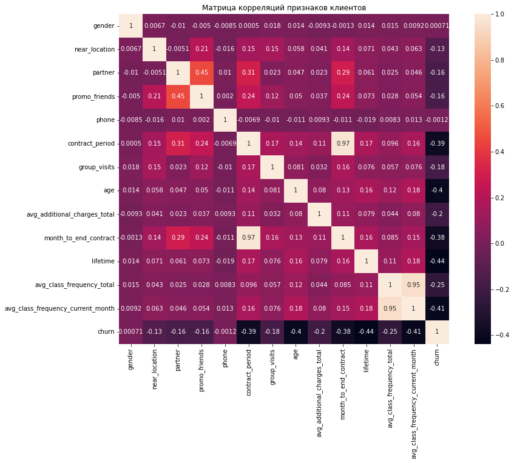

```python
cm = gym_data.corr()
fig, ax = plt.subplots(figsize=(15,10))
sns.heatmap(cm, annot=True, square=True)
plt.title('Матрица корреляций признаков клиентов')
plt.show()
```

Самые высокие показатели корреляции с целевым признаком `chun`(ушел или остался) у показателей `lifetime`, `avg_class_frequency_current_month`, `age`, `contract_period`, `month_to_end_contract`. С этими показателями корреляция отрицательная. Между собой ожидаемо сильно коррелируют `avg_class_frequency_current_month` и `avg_class_frequency_total`, `contract_period` и `month_to_end_contract`. Также матрица корреляций показывает высокую взаимосвязь между `partner` и `promo_friends`, `partner` и `contract_period`

**Предварительно можно сделать выводы:**

Клиенты обоих полов одинаково склонны к оттоку.

По остальным признакм к отткоу более склонны клиенты:

- у которых количество месяцев, прошедших после первого посещения 2 и меньше,
- возраста младше 25 лет,
- приобретающие абонемент на 1 месяц,
- не учавствующие в программах лояльности,
- не посещающие групповые занятия,
- не проживающие и не работающие в районе фитнес-центра,
- чья общая выручка по прочим услугам меньше 150 единиц,
- посещающющие в целом 1-2 занятия в неделю и в последний месяц меньше 1 занятия в неделю.

**Для дальнейшего анализа исключим по одному признаку из пар, сильно коррелирующих между собой.**

Удалим по 1 из наиболее сильно коррелирующих между собой признаков - период абонемнта и число месяцев до конца занятий, средняя посещаемость и средняя посещаемость в последний месяц. Оставим те, которые сильнее коррелируют с признаком `churn`:

- `contract_period`,
- `avg_class_frequency_current_month`.

```python
gym_data_new = gym_data.drop(['month_to_end_contract', 'avg_class_frequency_total'], axis = 1)
gym_data_new.columns
```

```
Index(['gender', 'near_location', 'partner', 'promo_friends', 'phone',
       'contract_period', 'group_visits', 'age',
       'avg_additional_charges_total', 'lifetime',
       'avg_class_frequency_current_month', 'churn'],
      dtype='object')
```

Можно приступать к машинному обучению.

## Модель прогнозирования оттока клиентов.

Построим модель бинарной классификации клиентов, где целевым признаком будет факт оттока клиентов в следующем месяце.

Обучим модель двумя способами - "Логистическая регрессия" и "Случайный лес".

**Функция, которя принимает на входе модель и данные и выводит метрики**

```python
def make_predictions(m, X_train, y_train, X_test, y_test):
    model = m(random_state=0)
    model.fit(X_train, y_train)
    y_pred = model.predict(X_test)
    y_proba = model.predict_proba(X_test)[:, 1]
    print('\tAccuracy: {:.2f}'.format(accuracy_score(y_test, y_pred)))
    print('\tPrecision: {:.2f}'.format(precision_score(y_test, y_pred)))
    print('\tRecall: {:.2f}\n'.format(recall_score(y_test, y_pred)))
```

Разделим данные на признаки (матрица X) и целевую переменную (y),

затем на обучающую и валидационную выборки

и стандартизируем признаки.

```python
X_n = gym_data_new.drop('churn', axis = 1)
y_n = gym_data_new['churn']

X_n_train, X_n_test, y_n_train, y_n_test = train_test_split(X_n, y_n, test_size=0.2, random_state=0, stratify = y_n)

scaler = StandardScaler()
scaler.fit(X_n_train)

X_n_train_st = scaler.transform(X_n_train)
X_n_test_st = scaler.transform(X_n_test)
```

Список моделей

```python
models = [
    LogisticRegression,
    RandomForestClassifier
]
name_models = [
    'Логистическая регрессия',
    'Случайный лес'
]
```

Применим функцию и посмотрим на метрики для каждой модели.

```python
for j, i in enumerate(models):
    print('Метрики для модели {}'.format(name_models[j]))
    make_predictions(i, X_n_train_st, y_n_train, X_n_test_st, y_n_test)
```

```
Метрики для модели Логистическая регрессия
	Accuracy: 0.92
	Precision: 0.85
	Recall: 0.84

Метрики для модели Случайный лес
	Accuracy: 0.91
	Precision: 0.85
	Recall: 0.77
```

**Вывод**

Нам важно совершить меньше ошибок предсказания, что клиент от нас уйдет - нужно выявить клиентов склонных к оттоку, и принимать меры по их удержанию.

Ключевым параметром для прогнозирования оттока, является доля правильных ответов для целевого класса. Поэтому целевой метрикой при выбре модели является `Recall`. Эта метрика лучше у Логистической регрессии.

## Кластеризация клиентов.

Стантартизируем данные для кластеризации.

```python
sc = StandardScaler()

X_n_sc = sc.fit_transform(X_n)

linked = linkage(X_n_sc, method = 'ward')
```

Построим матрицу рассотояний и отрисуем дендрограмму.

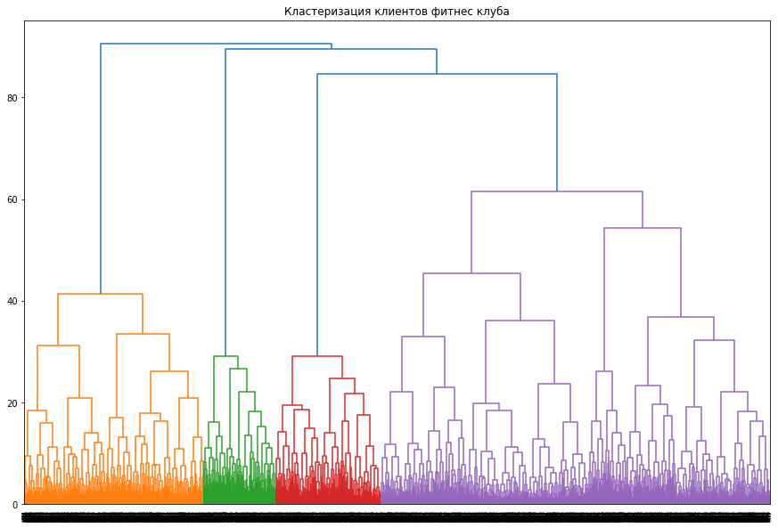

```python
plt.figure(figsize=(15, 10))
dendrogram(linked, orientation='top')
plt.title('Кластеризация клиентов фитнес клуба')
plt.show()
```

Дендрограмма определила оптимальное количество кластеров равное 4. Но мы разделим клиентов на 5 кластеров согласно заданию.

Обучим модель кластеризации алгоритмом K-Means и спрогнозируем кластеры клиентов. Столбец с кластерами добавим к таблице с данными.

Обучим модель кластеризации алгоритмом K-Means и спрогнозируем кластеры клиентов.

```python
km_new = KMeans(n_clusters=5, random_state=0)
labels_new = km_new.fit_predict(X_n_sc)
gym_data['cluster_km_new'] = labels_new
```

**Посмотрим на средние значения признаков в зависимости от кластера.**

```python
gym_data.groupby('cluster_km_new').mean().T
```

| cluster_km_new | 0 | 1 | 2 | 3 | 4 |
| --- | --- | --- | --- | --- | --- |
| gender | 0.496447 | 0.500000 | 0.500940 | 0.534260 | 0.523316 |
| near_location | 0.995939 | 0.000000 | 1.000000 | 0.996028 | 0.862694 |
| partner | 0.892386 | 0.489247 | 0.217105 | 0.379345 | 0.471503 |
| promo_friends | 1.000000 | 0.078853 | 0.072368 | 0.009930 | 0.305699 |
| phone | 1.000000 | 1.000000 | 1.000000 | 1.000000 | 0.000000 |
| contract_period | 6.922843 | 2.994624 | 2.010338 | 6.208540 | 4.777202 |
| group_visits | 0.524873 | 0.232975 | 0.277256 | 0.538232 | 0.427461 |
| age | 29.606091 | 28.679211 | 27.583647 | 30.699106 | 29.297927 |
| avg_additional_charges_total | 153.424651 | 137.125763 | 119.339956 | 176.259567 | 144.208179 |
| month_to_end_contract | 6.332995 | 2.818996 | 1.941729 | 5.650447 | 4.466321 |
| lifetime | 4.283249 | 2.974910 | 1.922932 | 5.415094 | 3.940415 |
| avg_class_frequency_total | 1.962217 | 1.764122 | 1.451098 | 2.322960 | 1.854211 |
| avg_class_frequency_current_month | 1.919520 | 1.597146 | 1.203319 | 2.324220 | 1.723967 |
| churn | 0.119797 | 0.403226 | 0.563910 | 0.014896 | 0.266839 |

Признаки, в средних значениях которых наибольшие различия между кластерами:

- большая часть клиентов проживающих или работающих не рядом с клубом собраны во 1-м кластере;
- самая высокая доля клиентов, учавствующих в партнерской программе в 0 кластере, самая низкая в 2-м;
- все клиенты в 0 кластере учавствуют в программе "Приведи другв", практически нет участников этой программы в 3 кластере (меньше 1%);
- все клиенты, не оставившие номер телефона собраны в 4-м кластере,
- клиенты с более длительными сроками абонементов собраны в 0 кластере, больше клиентов с меньшим сроком абонемента во 2-м кластере, соответственно распределены клиенты и по сроку до окончания абонемента ;
- меньше всего клиентов посещающих групповые занятия в 1-м кластере, больше всего в 3-м и 0-м;
- по среднему возрасту между кластерами различия небольшие - самый старший в 3-м кластере (почти 31 год), самый младший во 2-м (27,5 лет);
- клиенты приносящие наибольшую выручку собраны в 3-м и 0-м кластерах;
- также в 3-м и 0-м кластерах клиенты с самыми долгими периодами посещения клуба;
- клиенты посещающие в среднем большее количество занятий в неделю собраны в 3-м кластере, меньшее - во 2-м, соответстветственно распределены клиенты и по посещаемости в последний месяц;
- самая высокая доля оттока среди клиентов во 2-м кластере, самая низкая в 3-м и 0-м.

**Посмотрим на размеры кластеров**

```python
gym_data.groupby('cluster_km_new').agg({'churn' :'count'}).sort_values(by='churn', ascending=False)
```

| cluster_km_new | churn |
| --- | --- |
| 2 | 1064 |
| 3 | 1007 |
| 0 | 985 |
| 1 | 558 |
| 4 | 386 |

Самым большим оказался 2-й кластер, с наибольшей долей оттока клиентов.

**Посмотрим на распределение признаков в зависимости от кластера.**

**Построим графики распределения признаков, имеющих множество значений**

```
Графики распределения признаков со множеством значений в зависимости от кластера

Распределение клиентов по сроку абонемента в зависимости от кластера
```

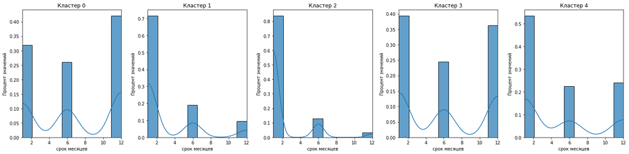

```
Распределение клиентов по возрасту в зависимости от кластера
```

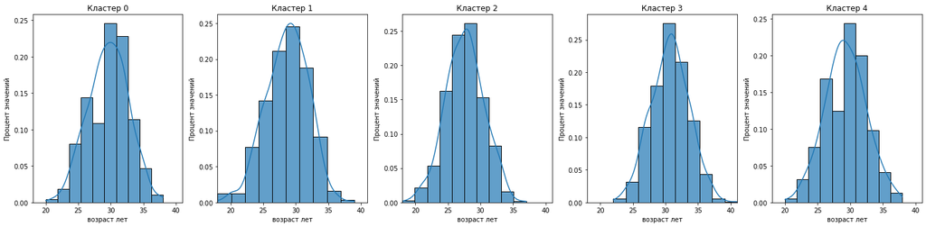

```
Распределение клиентов по суммарной выручке от др.услуг в зависимости от кластера
```

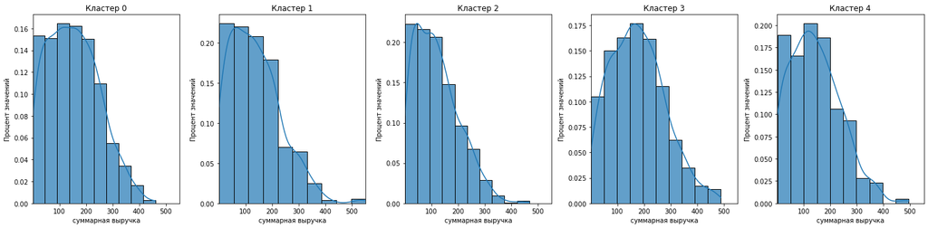

```
Распределение клиентов по кол-ву месяцев до конца абонемента в зависимости от кластера
```

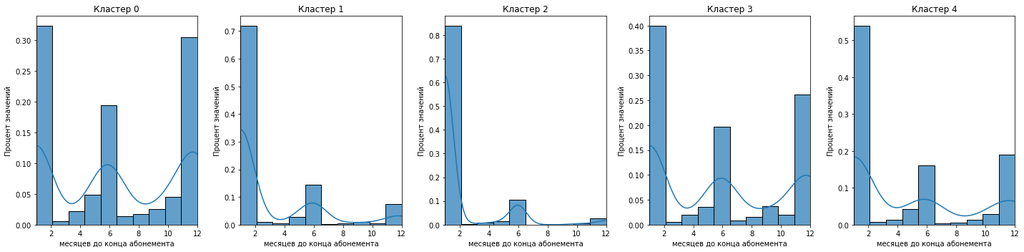

```
Распределение клиентов по кол-ву месяцев с первого посещения в зависимости от кластера
```

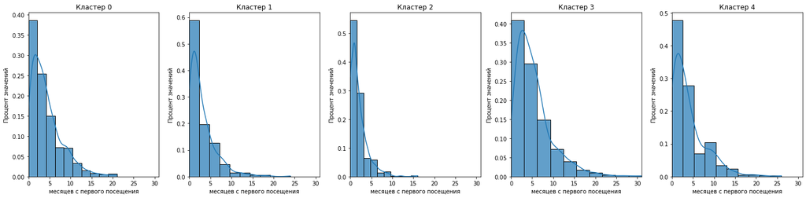

```
Распределение клиентов по общей посещаемости в неделю в зависимости от кластера
```

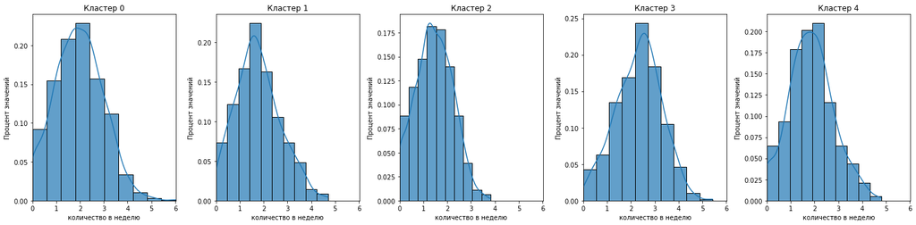

```
Распределение клиентов по посещаемости в неделю последний месяц в зависимости от кластера
```

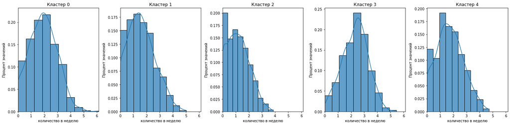

```python
selected_columns = [
    'contract_period',
    'age',
    'avg_additional_charges_total',
    'month_to_end_contract',
    'lifetime',
    'avg_class_frequency_total',
    'avg_class_frequency_current_month'
]
plot_names = [
    'сроку абонемента',
    'возрасту',
    'суммарной выручке от др.услуг',
    'кол-ву месяцев до конца абонемента',
    'кол-ву месяцев с первого посещения',
    'общей посещаемости в неделю',
    'посещаемости в неделю последний месяц'
]

x_names = [
    'срок месяцев',
    'возраст лет',
    'суммарная выручка',
    'месяцев до конца абонемента',
    'месяцев с первого посещения',
    'количество в неделю',
    'количество в неделю'
]
clusters = gym_data['cluster_km_new'].sort_values().unique()
print('Графики распределения признаков со множеством значений в зависимости от кластера\n')
for number, column in enumerate(selected_columns):
    print(f'Распределение клиентов по {plot_names[number]} в зависимости от кластера')
    plt.subplots(figsize=(20,5), sharey=True)
    for plot_num, cluster in enumerate(clusters):
        ax = plt.subplot(1, len(clusters), plot_num+1)
        sns.histplot(
            data=gym_data.query('cluster_km_new == @cluster'),
            x=column,
            stat='probability',
            common_norm=False,
            #hue='cluster_km',
            bins=10,
            kde = True,
            alpha=0.7
        )

        plt.title(f'Кластер {cluster}')
        plt.ylabel('Процент значений')
        plt.xlabel(x_names[number])
        plt.xlim(gym_data[column].min(), gym_data[column].max())
        #plt.legend.title('Кластер')
        plt.tight_layout()
    plt.show()
```

**Выводы**

Графики подтверждают выводы по средним значениям:

- основная часть клиентов с абонементами на 6 и 12 месяцев в 0-м и 3-м кластерах, в остальных преобладают клиенты с абонементом на 1 месяц;
- больше клиентов младше 30 лет в 1-м и 2-м кластерах;
- более высокие значения суммарной выручки характерны для 0 и 3-го кластеров;
- для всех кластеров кроме 0 и 3 характерен срок до окончания абонемента 1 месяц;
- в 0 и 3 кластерах больше клиентов посещающих клуб длительное время;
- для 3 кластера характерны наиболее высокие значения средней посещаемости в неделю;
- по распределению посещаемости в последний месяц можно сказать следующие:у клиентов в 0 и 3-м кластерах распределение соответствуют общей средней посещаемости, в других кластерах выросло число клиентов, посещающих меньше 1 занятия в неделю и пиковые значения сместились в меньшую сторону, во 2-м кластери появился пик практически на 0-м значении посещаемости.

**Распределение признаков, имеющих 2 значения.**

```
Графики распределения признаков, имеющих 2 значения в зависимости от кластера
```

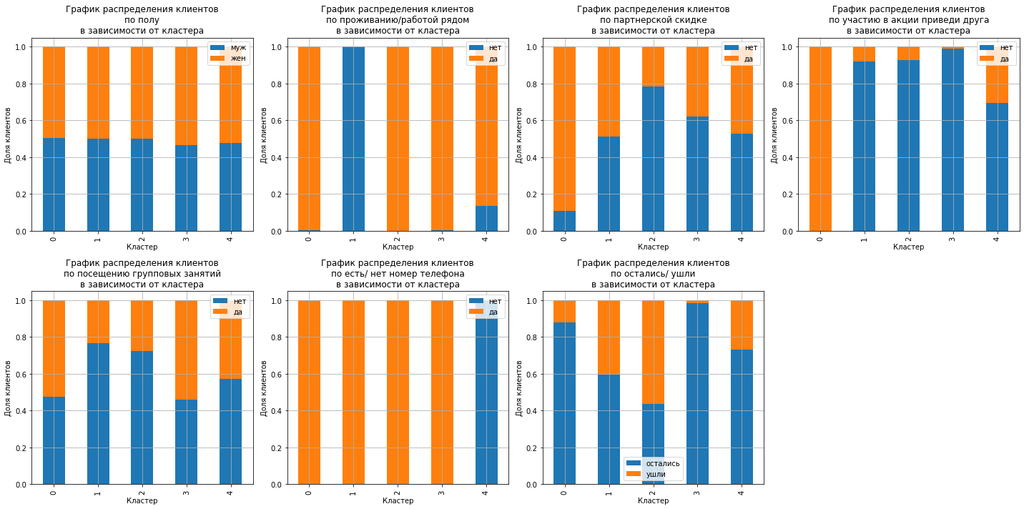

```python
print('Графики распределения признаков, имеющих 2 значения в зависимости от кластера')
plt.subplots(figsize=(20,10))
selected_columns = [
    'gender',
    'near_location',
    'partner',
    'promo_friends',
    'group_visits',
    'phone',
    'churn'
]
plot_names = [
    'полу',
    'проживанию/работой рядом',
    'партнерской скидке',
    'участию в акции приведи друга',
    'посещению групповых занятий',
    'есть/ нет номер телефона',
    'остались/ ушли'
]

x_names = [
    ['муж', 'жен'],
    ['нет', 'да'],
    ['нет', 'да'],
    ['нет', 'да'],
    ['нет', 'да'],
    ['нет', 'да'],
    ['остались', 'ушли']
]
for plot_num, column in enumerate(selected_columns):
    ax = plt.subplot(2, len(selected_columns)-3,plot_num+1)
    tab = (
        gym_data
        .pivot_table(index='cluster_km_new', columns=column, values='lifetime', aggfunc='count')
    )
    tab.div(tab.sum(axis=1), axis=0).plot(kind='bar', stacked=True, grid=True, ax=ax)
    plt.title(f'График распределения клиентов\nпо {plot_names[plot_num]}\nв зависимости от кластера')
    plt.legend(x_names[plot_num])
    plt.xlabel('Кластер')
    plt.ylabel('Доля клиентов')
    plt.tight_layout()
```

**Выводы**

Графики подтверждают выводы по средним значениям:

- распределение по полу в целом одинаковое, только в 3-м кластере чуть больше женщин;
- практически все клиенты, не проживающие рядом с клубом собраны в 1-м кластер, также в 4-м кластере около 14% таких клиентов;
- самые высокие доли участников партнерской порграммы и акции "приведи друга" в 0 кластере, меньше всего участников партнерской программы во 2-м кластере, участников акции "приведи друга" - в 3-м кластере;
- среди клиентов 1-го кластера наименьшая доля посещающих групповые занятия;
- самая большая доля ушедших клиетов во 2-м кластере, самые низкая в 3-м.

Для наглядности посчитаем долю оттока в каждом кластере

```python
churn_by_clusters = (
    gym_data.groupby('cluster_km_new')
    .agg({'churn':'mean'})
    .round(2)
    .sort_values(by='churn', ascending=False)
)
churn_by_clusters
```

| cluster_km_new | churn |
| --- | --- |
| 2 | 0.56 |
| 1 | 0.40 |
| 4 | 0.27 |
| 0 | 0.12 |
| 3 | 0.01 |

Наиболее склонны к оттоку клиенты из 1 и 2 кластеров. Самыми надежными можно назвать клиентов из 3 и 0 кластеров.

## Основные выводы и рекомендации.

В ходе исследовательского анализа мы выявили признаки наиболее сильно влияющие на отток:

- число месяцев со дня первого посещения (новые клиенты более склонны к оттоку)
- среднее число занятий в неделю за последний месяц - у клиентов склонных к оттоку число занятий в последнем месяце заметно сокращается;
- возраст - клиенты младшее 27 лет более склонны к оттоку;
- период абонемента и число месяцев до его окончания - клиенты купившие абонемент на 1 месяц значительно больше склонны к оттоку, также увеличивается вероятность оттока с окончанием абонемента. Кроме того, мы выявили, что в целом вероятность оттока меньше у клиентов посещающих групповые занятия, а также у клиентов, склонных приобретать дополнительные услуги клуба.

Вторым этапом мы получили модель прогнозирования оттока клиента в следующем месяце. Обучение модели проводили двумя методами - Логистическая регрессия и Случайный лес.

При выборе модели мы ориентировались на долю правильных ответов для целевого класса. По этому параметру (полноте (Recall)) Логистическая регрессия показала себя лучше.

В процессе кластеризациии клиентов клуба разделили на 5 кластеров.

Наиболее склонны к оттоку клиенты из 2-го кластера. Отличительными характеристиками этого кластера являются: более младший возраст клиентов, наибольшая доля клиентов с месячным абонементом, низкая еженедельная посещаемость и еще большее ее снижение в последний месяц.

**Рекомендации**

Целевой группой для клуба должны стать клиенты старше 27 лет, приобретающие долгосрочные абонементы. Привлечь таких клиентов может расширение партнерской программы. Кроме того клиенты участники партнерской программы более склонны к покупке долгосрочных абонементов (между этими признаками довольно высокая корреляция).

Очень важно следить за посещаемостью клиентов. В случае снижения выяснять причины, возможно рекомендовать альтернативные программы тренировок.

Также следует расширить программу лояльности для удержания новых клиентов, имеющих месячный абонемент. Как вариант предлагать в течении первого месяца посещений приобрести годовой абонемент со скидкой.